# Introdução ao Consultasocio

Gabriel Pistelli Ferreira

2022-09-20

```r
library(Consultasocio)
library(stringr) # Para manusear strings
library(httr) # Para usar a API do web.archive
library(FactoMineR) # Para AGD
library(factoextra) # Para AGD
```

## Introdução ao pacote

Quando se registra uma empresa, exige-se um preenchimento de dados sobre esta, assim como estes dados também são exigidos para a declaração de impostos de renda da pessoa jurídica. Ou seja, por mais que estas informações sejam muitas vezes – pela própria lógica de sua exigência (cobrança de tributos, controle de dívidas e patrimônio, etc.) – manipuladas e controladas pelos proprietários das empresas, temos uma fonte de dados imensa sobre estas, mas que infelizmente, é pouco explorada na sociologia do empresariado. Isto se dá porque estes dados não são de fácil acesso e, mesmo que o sejam, aind são extremamente descentralizados e descontinuados, o que dificulta a investigação consistente com estes dados.

Algumas alternativas, como o [Socios Brasil](https://brasil.io/dataset/socios-brasil/), assim como os sites próprios do governo (tais quais os [Dados Públicos CNPJ da Receita](https://www.gov.br/receitafederal/pt-br/assuntos/orientacao-tributaria/cadastros/consultas/dados-publicos-cnpj) e a [Redesim](https://consultacnpj.redesim.gov.br/)), tem oferecido estes dados, mas, alguns problemas persistem, como: tamanho, desatualização e falta de dados, instabilidade de acesso, acesso restrito ao CNPJ, etc. Estes problemas dificultam a operacionalização de qualquer pesquisa, mas, em especial, não favorecem o estudo das propriedades individuais de um sujeito específico, método mais utilizado nas prosopografias e sociografias nas áreas de ciências sociais.

Neste sentido, uma das alternativas que buscamos propor está a pesquisa através do [Consultasocio](https://www.consultasocio.com), um site especializado no tema que reúne dados públicos de proprietários em um único endereço eletrônico. Estes dados, por mais que não estejam estruturados e organizados em uma planilha, são mais amplos (uma vez que incluem informações como número de funcionários, número de empresas ativas e baixadas, sócios, etc.) e organizados em torno do proprietário, o que facilita e potencializa uma pesquisa significativa com esta plataforma.

Além disso, os dados são atualizados com certa frequência, mas, por outro lado, não temos como observar os dados anteriores através do próprio site, o que é uma desvantagem. Outra desvantagem significativa é o fato de que o site não permite a extração automatizada de seus dados, o que contornamos a partir da união do útil e agradável: já que não temos condições de extrair estes dados diretamente da fonte, primeiro precisamos arquivá-los em outro local, o que nos permite também ter acesso às versões anteriores de suas páginas.

Estas particularidades todas, portanto, demandam um planejamento de mineração de dados que nos levou à criação deste pacote, juntando funções com o papel de armazenar, extrair dados e processá-los. A aplicação e interpretação estatística fica por conta de pacotes externos, mas, considerando-se o formato de nossos dados (categóricos) e nossa verve teórica, apresentaremos a aplicação de uma ACM com nosso pacote.

Iremos demonstrar, nesta introdução, como organizar a sua planilha de pesquisa, ler os dados e, por fim, como aplicar a ACM neste data.frame. Nos limitamos a apenas apresentar os elementos básicos de investigação de nível de capital proposto em nosso artigo apresentado na ANPOCS: “Mapeando a composição econômica de entidades empresariais: proposição de um método espacial”. Ou seja, outras funções, como ler o quadro de sócios, traçar a abertura de empresas , etc., não será feita por aqui. Depois de alguns testes e contribuições de outros pesquisadores, pretendemos adicionar estes elementos em nosso pacote, mas não conseguimos o fazer no momento.

## Instalação e citação

Para instalar nosso pacote, basta usar as linhas a seguir:

```r
# Se você não tem o devtools instalado, instale-o:
install.packages("devtools")

# A partir daí é só colocar o próximo código:
devtools::install_github(repo = "gpistelli/Consultasocio")
```

A base da citação pode ser:

```r
FERREIRA, Gabriel Pistelli. Consultasocio. R Package version 0.1. 2022. Disponível em: <https://github.com/gpistelli/Consultasocio>.
```

Se encontrar algum bug, tiver qualquer sugestão ou algo mais, pode entrar em contato com o criador do pacote a partir dos dados dispostos em sua [conta do github](https://github.com/gpistelli) ou [página da internet](https://gpistelli.github.io).

## Organizando a planilha de pesquisa

Decidimos programar nosso pacote para começar com um instrumento clássico dos pesquisadores de ciências sociais: uma planilha.

Recomendamos organizar a planilha em seis colunas:

1. ID do indivíduo: nome, alcunha ou código escolhido pelo pesquisador para identificação.
2. Afiliação a determinado grupo: pode ser uma entidade, partido, movimento, etc., o que for parte de sua questão de pesquisa.
3. CPF: indicador do CPF, o qual só deve ser colocado em casos nos quais se tenha homônimos.
4. Link: Aqui estarão os links do web.archive, com os casos com mais de uma página devidamente unidos a partir de vírgula – para termos uma string e não um vetor.
5. Consulta: O link original do Consultasocio desta pessoa.
6. Pages: O número de páginas do Consultasocio.

Para exemplificar o uso do pacote, vamos realizar nossos exemplos a partir de uma planilha na qual adicionamos candidatos a governador e vice-governador do Estado do Paraná em 2022 com propriedades de empresas (e mais Ricardo Barros, para fecharmos em 10 casos). Sendo assim, aqui está um exemplo de como sua planilha deve ficar:

```r
candidatos <- read.csv(file = "candidatos.csv", fileEncoding = "utf8", colClasses = "character")

candidatos[2:ncol(candidatos)]
```

| Candidatos | Partido | CPF | Link | Consulta | Pages |
| --- | --- | --- | --- | --- | --- |
| Barros | PP | NA | https://web.archive.org/web/20220826202931/https://www.consultasocio.com/q/sa/ricardo-jose-magalhaes-barros,https://web.archive.org/web/20220826202954/https://www.consultasocio.com/q/sa/ricardo-jose-m… | https://www.consultasocio.com/q/sa/ricardo-jose-magalhaes-barros | 2 |
| Osni | PMN | NA | https://web.archive.org/web/20220826203009/https://www.consultasocio.com/q/sa/osni-francisco-minotto | https://www.consultasocio.com/q/sa/osni-francisco-minotto | 1 |
| Requião | PT | NA | https://web.archive.org/web/20220826203028/https://www.consultasocio.com/q/sa/mauricio-requiao-de-mello-e-silva | https://www.consultasocio.com/q/sa/mauricio-requiao-de-mello-e-silva | 1 |
| Samek | PT | NA | https://web.archive.org/web/20220826203044/https://www.consultasocio.com/q/sa/jorge-miguel-samek | https://www.consultasocio.com/q/sa/jorge-miguel-samek | 1 |
| Joni | DC | NA | https://web.archive.org/web/20220826203103/https://www.consultasocio.com/q/sa/joni-silva-correia-junior | https://www.consultasocio.com/q/sa/joni-silva-correia-junior | 1 |
| Gledson | DC | NA | https://web.archive.org/web/20220826203120/https://www.consultasocio.com/q/sa/gledson-regnier-zawadzki | https://www.consultasocio.com/q/sa/gledson-regnier-zawadzki | 1 |
| Gomyde | PDT | NA | https://web.archive.org/web/20220826203217/https://www.consultasocio.com/q/sa/ricardo-crachineski-gomyde | https://www.consultasocio.com/q/sa/ricardo-crachineski-gomyde | 1 |
| Eliza | PDT | 701059 | https://web.archive.org/web/20220826203231/https://www.consultasocio.com/q/sa/eliza-ferreira-da-silva | https://www.consultasocio.com/q/sa/eliza-ferreira-da-silva | 1 |
| Ratinho | PSC | NA | https://web.archive.org/web/20220826184213/https://www.consultasocio.com/q/sa/carlos-roberto-massa-junior | https://www.consultasocio.com/q/sa/carlos-roberto-massa-junior | 1 |
| Piana | PSC | NA | https://web.archive.org/web/20220826203304/https://www.consultasocio.com/q/sa/darci-piana | https://www.consultasocio.com/q/sa/darci-piana | 1 |

Será a partir desta planilha que nosso algoritmo lerá as informações e organizará os procedimentos para extrair os dados corretamente. Escolhemos este caminho porque uma automatização completa deste processo é bastante difícil, por conta de imprevisibilidades do Consultasocio e possível falta de dados para os pesquisadores.

A planilha, então, serve de base para termos uma relação anterior dos agentes a serem pesquisados. Isto permite que os pesquisadores explicitem seus objetos e garantam transparência em sua investigação.

Nossa planilha exemplificativa já está com as páginas arquivadas, as quais o fizemos através de um processo automatizado. Apenas como um modelo básico, podemos ver logo abaixo um exemplo de código utilizado para armazenar os links do Consultasocio. O nosso procedimento, basicamente, foi o seguinte:

1. Coletamos os links dispostos na coluna `Consulta`, ajustamos os números de páginas presentes para aquele indivíduo, os guardamos em um novo vetor e filtramos para termos apenas as células preenchidas.
2. Em seguida, salvamos as páginas selecionadas através da API do Web Archive, organizada na função `WArch_store_page`. Para maiores informações sobre seu funcionamento e como conseguir a chave de acesso, cheque a sua [documentação](https://docs.google.com/document/d/1Nsv52MvSjbLb2PCpHlat0gkzw0EvtSgpKHu4mk0MnrA/).
3. Por fim, adicionamos os links do web.archive nas suas respectivas linhas em nossa planilha e salvamos este arquivo no formato .csv.

```r
links <- character()
for (i in 1:nrow(candidatos)){
  if (candidatos$Pages[i] > 1){
  links  <- c(links, candidatos$Consulta[i], paste0(candidatos$Consulta[i], "?page=", 2:candidatos$Pages[i]))
  } else {
  links <- c(links, candidatos$Consulta[i])
  }
}

links <- links[str_length(links) > 1]

key <- "xxxxxxx" # Sua chave
secret <- "yyyyyyy" # Sua senha

WArch_links <- unlist(lapply(X = links, FUN = WArch_store_page, WArch_auth = paste0(key, " <", secret, ">")))

for (i in 1:nrow(candidatos)){
  if (str_length(candidatos$Consulta[i]) < 2){
    print(paste0("Row n.", i , ": Consultasocio link wasn't provided"))
  } else {
    pos <- grep(pattern = candidatos$Consulta[i], x = WArch_links, fixed = T)
      }

  if (length(pos) > 1){
      candidatos$Link[i] <- paste0(WArch_links[pos], collapse = ",")
    } else {
      candidatos$Link[i] <- WArch_links[pos]
    }
  }
}

candidatos$CPF[stringr::str_length(candidatos$CPF) < 1] <- NA
write.csv(x = candidatos, file = "candidatos.csv", fileEncoding = "utf8")
```

Após armazenar os links e salvá-los em sua planilha, podemos ler esses dados a partir de duas funções principais:

| Função | Descrição |
| --- | --- |
| `CS_read_board_csv` | Diretamente da planilha selecionada, através do acesso à internet. Como todo trabalho através da internet, temos certa instabilidade com este método. |
| `CS_read_files_backup` | A partir de backups destas páginas, como fazemos em nosso artigo. Recomendado para o estudo de diretorias de entidades, uma vez que foi concebido com este fim. |

A função 2 está organizada pensando no estudo de entidades empresariais: organiza e lê os dados a partir da divisão em entidades e período da gestão. Por isso, não a utilizaremos aqui e, se quiser ver como a utilizamos, cheque o [repositório](https://github.com/gpistelli/Federacoes_Ind) de nosso artigo apresentado no GT 7 do 46º Encontro Nacional da ANPOCS (2022).

As duas funções, entretanto, passam pelo mesmo procedimento, que é, basicamente, ler linha a linha os links do web.archive disponibilizados na planilha, extrair os dados ali presentes e processá-los em variáveis por nós definidas. Contudo, antes de apresentar o produto final, precisamos analisar as páginas dos proprietários, as quais fazemos através da função auxiliar `CS_get_bus_df`, a qual nos retorna um data.frame com todos os dados das empresas do Consultasocio. Vejamos um exemplo com o caso de Ratinho Junior.

Primeiro baixamos o arquivo, para evitar instabilidades:

```r
download.file(candidatos$Link[9], destfile = "ratinho.html", quiet=TRUE)
```

E, em seguida, lemos diretamente da fonte:

```r
ratinho <- CS_get_bus_df("ratinho.html")

ratinho
```

| Data.de.entrada | CNPJ | Razão.social | Situação.Cadastral | Endereço | Capital.social | Atividade.econômica | Natureza.jurídica | Faturamento | Número.de.funcionários | Porte | Simples.Nacional | Data.de.abertura | Telefone.de.contato | E-mail | Nome.fantasia |
| --- | --- | --- | --- | --- | --- | --- | --- | --- | --- | --- | --- | --- | --- | --- | --- |
| 15/04/2011. | 10.424.932/0001-15 | Agropastoril Cafe No Bule Ltda | ATIVA. | Estrada Pirapo-Sao Pedro, Km 07, Rodovia Erwin Schindler, S/N, Fazenda UbatubaZona Rural, Apucarana, PR, CEP 86800-970, Brasil | R$ 35.848.384,00. | Cultivo de soja (0115600). | Sociedade Empresária Limitada (2062). | De R$2.400.000,00 a R$5.000.000,00. | Entre 100 E 199 Funcionarios (Media). | Média Empresa. | Não optante. | 14/10/2008 | (41) 30749090 / (41) 30749090 / FAX | [email protected] | NA |
| 15/04/2011. | 10.424.932/0002-04 | Agropastoril Cafe No Bule Ltda | ATIVA. | Rua Joao Tschannerl, 830, Bloco AVista Alegre, Curitiba, PR, CEP 80820-010, Brasil | R$ 35.848.384,00. | Cultivo de soja (0115600). | Sociedade Empresária Limitada (2062). | NA | NA | NA | Não optante. | 02/04/2009 | (41) 30919166 / (41) 30919159 / FAX | [email protected] | NA |
| 15/04/2011. | 10.424.932/0003-87 | Agropastoril Cafe No Bule Ltda | ATIVA. | Estrada Estrada Do Ubauna, Km10, Fazenda Costa Rica, Sao Joao Do Ivai, PR, CEP 86930-000, Brasil | R$ 35.848.384,00. | Cultivo de soja (0115600). | Sociedade Empresária Limitada (2062). | NA | NA | NA | Não optante. | 12/03/2020 | (41) 30919074 | [email protected] | NA |
| 22/07/2009. | 11.013.676/0001-36 | Jr2 Producao e Promocoes Ltda | BAIXADA. | Rua Darcy Setim, 205, Andar 1 Sala 2Boneca Do Iguacu, Sao Jose Dos Pinhais, PR, CEP 83040-220, Brasil | R$ 20.000,00. | Artes cênicas, espetáculos e atividades complementares não especificadas anteriormente (9001999). | Sociedade Empresária Limitada (2062). | NA | NA | NA | Não optante. | 22/07/2009 | (41) 30919172 / (41) 30919166 / FAX | [email protected] | NA |
| 29/03/2017. | 19.070.553/0001-49 | Empreendimento Residencial Cinque Terre Ltda. | BAIXADA. | Rua Gardenio Scorzato, 220, Vista Alegre, Curitiba, PR, CEP 82100-240, Brasil | R$ 9.040.706,00. | Incorporação de empreendimentos imobiliários (4110700). | Sociedade Empresária Limitada (2062). | De R$240.000,00 a R$2.400.000,00. | Entre 20 E 99 Funcionarios (Epp). | Pequena Empresa. | Não optante. | 04/10/2013 | (41) 30293221 / (41) 30293221 / FAX | [email protected] | Empreendimento Residencial Cinque Terre. |
| 19/04/2011. | 81.261.364/0001-27 | Massa & Massa Comunicacao e Marcas Ltda | ATIVA. | Rua Waldomiro De Souza Hathy, 36, Andar 1 Sala 2-BCentro, Campina Grande Do Sul, PR, CEP 83430-970, Brasil | R$ 89.100,00. | Agenciamento de espaços para publicidade, exceto em veículos de comunicação (7312200). | Sociedade Empresária Limitada (2062). | De R$10.000.000,00 a R$30.000.000,00. | Entre 50 E 199 Funcionarios (Media). | Média Empresa. | Não optante. | 08/06/1989 | (41) 30919166 / (41) 30919167 / FAX | [email protected] | NA |
| 19/04/2011. | 81.261.364/0002-08 | Massa & Massa Comunicacao e Marcas Ltda | BAIXADA. | Rua Ver.Rosemiro F.Santos, 80, Jd.Ipanema, Campina Grande Do Sul, PR, CEP 83430-000, Brasil | R$ 89.100,00. | Agências de publicidade (7311400). | Sociedade Empresária Limitada (2062). | De R$10.000.000,00 a R$30.000.000,00. | Entre 50 E 199 Funcionarios (Media). | Média Empresa. | Não optante. | 25/09/1997 | NA | NA | NA |

A partir deste data.frame, processamos ele novamente e recebemos um vetor que, depois, será juntado a outros por meio da função `dplyr::bind_rows`, formando um data.frame com as mesmas posições que as de nossa planilha original, o que permitirá a utilização dos IDs presentes nesta. Aqui está um exemplo deste vetor, com os dados do governador Ratinho Junior:

```r
ratinho_vec <- CS_get_summary_vec_reg(ratinho)

ratinho_vec
```

```
##        N_Emp Maior_n_Func    Maior_Fat         KSoc          Agr         Serv
##          "7"          "6"          "5"   "44998190"          "y"          "y"
##       Constr          Sul
##          "y"          "y"
```

Os dados que estão em variáveis contínuas e ordinais são, posteriormente, a partir de uma das duas funções principais, convertidos em categóricos.

Voltando às nossas funções principais, a função 1, a qual recomendamos para estudos com um pequeno número de casos, pode ser aplicada da seguinte forma:

```r
df <- CS_read_board_csv(csv_path = "candidatos.csv",
                        only_bus = T,
                        active_bus = F,
                        Maior_n_Func_labels = c(rep("Até 19 Func", 2), rep("20-99 Func", 2), rep("100-199 Func", 2),
                                                "Mais de 200 Func"),
                        Maior_Fat_labels = c("Até 240k Fat", "Até 2,4M Fat", "De 2,4 a 5M Fat", rep("Mais de 5M Fat", 5)),
                        N_Emp_breaks = c(-1, 1, 5, Inf),
                        N_Emp_labels = c("Até 1 Emp", "2 a 5 Emp", "Mais de 5 Emp"),
                        KSoc_breaks = c(-1, 100000, 1000000, 10000000, Inf),
                        KSoc_labels = c("Até 100k KSoc", "100k a 1M KSoc", "1M a 10M KSoc", "Mais de 10M KSoc")

)

df$Partido <- candidatos$Partido

row.names(df) <- candidatos$Candidatos

write.csv(x = df, file = "summary_candidatos.csv", row.names = T, fileEncoding = "utf8")
```

Lembramos, novamente, que este método pode apresentar instabilidades e que, de fato, a forma mais rápida e efetiva para leitura dos dados ainda seria através do backup, ainda mais se este for utilizado para disponibilizar arquivos aos pesquisadores que forem replicar sua pesquisa. O data.frame resultante deste código pode ser visto a seguir, com as alterações já afirmadas anteriormente:

```r
df <- read.csv("summary_candidatos.csv", fileEncoding = "utf8", row.names = 1)

df
```

|  | N_Emp | Maior_n_Func | Maior_Fat | KSoc | Constr | Serv | Transf | Sul | Comerc | Agr | Centro.Oeste | Extr | Infra | Norte | Nordeste | Sudeste | Partido |
| --- | --- | --- | --- | --- | --- | --- | --- | --- | --- | --- | --- | --- | --- | --- | --- | --- | --- |
| Barros | Mais de 5 Emp | 20-99 Func | Até 2,4M Fat | 1M a 10M KSoc | y | y | y | y | n | n | n | n | n | n | n | n | PP |
| Osni | 2 a 5 Emp | 20-99 Func | Até 2,4M Fat | 100k a 1M KSoc | y | y | n | y | y | n | n | n | n | n | n | n | PMN |
| Requião | 2 a 5 Emp | 20-99 Func | Até 2,4M Fat | Até 100k KSoc | n | y | n | y | y | n | n | n | n | n | n | n | PT |
| Samek | Até 1 Emp | 100-199 Func | De 2,4 a 5M Fat | 1M a 10M KSoc | y | n | n | y | n | n | n | n | n | n | n | n | PT |
| Joni | 2 a 5 Emp | Até 19 Func | Até 240k Fat | Até 100k KSoc | n | y | n | y | n | n | n | n | n | n | n | n | DC |
| Gledson | 2 a 5 Emp | 100-199 Func | De 2,4 a 5M Fat | Até 100k KSoc | n | y | n | y | n | n | n | n | n | n | n | n | DC |
| Gomyde | 2 a 5 Emp | NA | NA | Até 100k KSoc | n | y | n | y | n | n | n | n | n | n | n | n | PDT |
| Eliza | 2 a 5 Emp | Até 19 Func | Até 240k Fat | Até 100k KSoc | n | y | n | y | n | n | n | n | n | n | n | n | PDT |
| Ratinho | Mais de 5 Emp | 100-199 Func | Mais de 5M Fat | Mais de 10M KSoc | y | y | n | y | n | y | n | n | n | n | n | n | PSC |
| Piana | Mais de 5 Emp | 100-199 Func | De 2,4 a 5M Fat | Até 100k KSoc | n | y | n | y | y | n | y | n | n | n | n | n | PSC |

Temos, então, uma sistematização dos dados das empresas dos indivíduos pesquisados, apresentando as seguintes colunas:

| Variável | Descrição |
| --- | --- |
| N_Emp | Número de empresas registradas no nome desta pessoa. Pode-se escolher, como parâmetros, se se deve buscar apenas empresas ativas (only_active) e/ou se se deve excluir as associações. |
| Maior_n_Func | Maior número de funcionários dentre as empresas do indivíduo/grupo. |
| Maior_Fat | Maior faturamento dentre as empresas do indivíduo/grupo. |
| KSoc | Soma dos valores únicos de capital social na empresa. Escolhemos este procedimento para evitar a soma repetida de capitais sociais. |
| Constr, Serv, Transf, Comerc, Agr, Extr e Infra | Possui empresa com atividade principal neste setor (feita a partir da CNAE). |
| Sul, Centro Oeste, Sudeste, Nordeste e Norte | Possui empresas na região em questão |

A escolha destas variáveis se deu pelo nosso objeto de estudo. Por isso, novos métodos podem ser desenvolvidos, inclusive utilizando-se novos cortes e classificação dos dados, de acordo com as necessidades de cada pesquisador.

## Análise dos dados

Em nível exploratório, uma vez que estamos tratando um dataset pequeno, podemos ter uma ideia geral destes dados a partir da função `summary`:

```r
df[1:17] <- lapply(df[1:17], as.factor)
summary(df)
```

```
##            N_Emp         Maior_n_Func           Maior_Fat               KSoc
##  2 a 5 Emp    :6   100-199 Func:4     Até 2,4M Fat   :3   100k a 1M KSoc  :1
##  Até 1 Emp    :1   20-99 Func  :3     Até 240k Fat   :2   1M a 10M KSoc   :2
##  Mais de 5 Emp:3   Até 19 Func :2     De 2,4 a 5M Fat:3   Até 100k KSoc   :6
##                    NA's        :1     Mais de 5M Fat :1   Mais de 10M KSoc:1
##                                       NA's           :1
##
##  Constr Serv  Transf Sul    Comerc Agr   Centro.Oeste Extr   Infra  Norte
##  n:6    n:1   n:9    y:10   n:7    n:9   n:9          n:10   n:10   n:10
##  y:4    y:9   y:1           y:3    y:1   y:1
##
##
##
##
##  Nordeste Sudeste Partido
##  n:10     n:10    DC :2
##                   PDT:2
##                   PMN:1
##                   PP :1
##                   PSC:2
##                   PT :2
```

Nossa ideia principal, ao criar este pacote e assim organizar estes dados, sempre foi interpretá-los a partir do método geométrico de análise de dados, mais especificamente a partir de sua representação espacial, a qual nos permite medir as posições destes agentes e suas entidades a partir de dados categóricos. Por isso, apresentamos aqui uma breve análise a partir deste método.

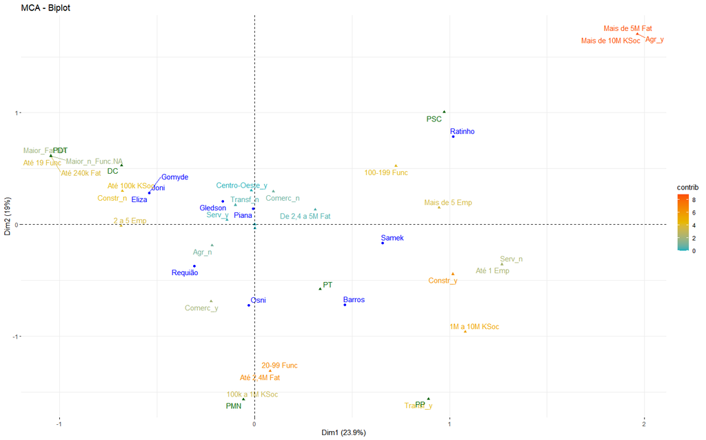

ACM

```r
df_mca <- MCA(X = df, quali.sup = 17, graph = F)

fviz_mca_biplot(df_mca, axes = c(1, 2), col.var = "contrib", gradient.cols = c("#00AFBB", "#E7B800", "#FC4E07"), repel = T)
```

Como nosso gráfico demonstra, Ratinho Junior, Jorge Samek e Ricardo Barros são os políticos com propriedades maiores, sendo o herdeiro da família Massa o mais isolado nesta dimensão. Piana, Osni, Requião e Gleidson seriam mais próximos a um capital médio e Gomyde, Eliza e Joni teriam os menores capitais econômicos.

Além disso, algumas associações esquisitas podem ser vistas, como a proximidade entre as categorias `Até 1 Emp` e `Mais de 5 Emp`: isto se deve ao fato de Samek possuir apenas uma empresa com tamanho maior, enquanto os outros com mais de cinco empresas também possuíam pelo menos uma de maior porte.

Podemos ver que a “intrusa” neste caso é a categoria `Até 1 Emp`, uma vez que esta possui menor contribuição que as outras. Em uma análise espacial com mais casos, Samek não estaria posicionado tão à frente nesta dimensão de nível de capital, ocupando um espaço intermediário, assim como a categoria `Até 1 Emp` estaria no lado oposto, representando a ausência de capital econômico. Para se ver um exemplo de composição espacial mais consistente, confira nosso artigo apresentado na ANPOCS.

Outro elemento presente nesta ACM, são as variáveis suplementares – neste caso, os partidos políticos. Claramente não podemos utilizar esta análise como real, uma vez que é muito pequena e restrita, mas, se esta análise fosse válida, poderíamos interpretar que a coligação de Ratinho seria de longe a com candidatos com melhores condições econômicas, assim como a do PDT seria significativamente a com menor nível de capital.

## Referências

ATKINSON, Will. The Class Structure of Capitalist Societies. Nova Iorque: Routledge, 2020

CONSULTASOCIO. Disponível em: https://www.consultasocio.com

JUSTEN, Álvaro. Sócios Brasil. Disponível em: https://brasil.io/dataset/socios-brasil/

KASSAMBARA, Alboukadel; MUNDT, Fabian Mundt. factoextra: Extract and Visualize the Results of Multivariate Data Analyses. R package version 1.0.7. 2020. Disponível em: https://CRAN.Rproject.org/package=factoextra.

LE, Sebastien; JOSSE, Julie; HUSSON, Francois. FactoMineR: An R Package for Multivariate Analysis. Journal of Statistical Software, 25(1), 2008.

REDESIM. Disponível em: https://consultacnpj.redesim.gov.br/

WAYBACK MACHINE. Disponível em: https://web.archive.org/

WICKHAM, Hadley. rvest: Easily Harvest (Scrape) Web Pages. R package version 0.3.6. 2020. Disponível em: https://CRAN.R-project.org/package=rvest.

_____; et al. Welcome to the tidyverse. Journal of Open Source Software, 4(43), 1686, 2019.